# Los inicios de Tidyverse

Curso: Introducción a Ciencia de Datos

Autores/as

Dr. Gustavo Giménez

Mg. Ana Haique

Fecha de publicación

6 de agosto de 2026

# Qué es Tidyverse?

[figure not shown]

Librerías de tidyverse

Es una colección para ciencia de datos.

## Autores

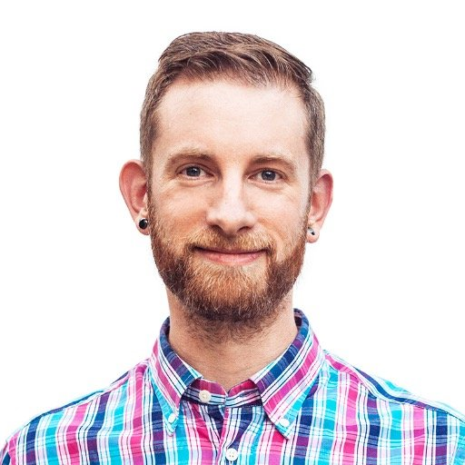

Hadley Wickham

Hadley Wickham, Mara Averick, Jennifer Bryan, Winston Chang, Lucy D’Agostino McGowan, Romain François, Garrett Grolemund, Alex Hayes, Lionel Henry, Jim Hester, Max Kuhn, Thomas Lin Pedersen, Evan Miller, Stephan Milton Bache, Kirill Müller, Jeroen Ooms, David Robinson, Dana Paige Seidel, Vitalie Spinu, Kohske Takahashi, Davis Vaughan, Claus Wilke, Kara Woo, Hiroaki Yutani

## ¿Qué significa **tidyverse**?

### **Tidy**

> **“Tidy”** significa **ordenado**.

Hace referencia a los **datos tidy**, concepto formalizado por Hadley Wickham (2014):

- Cada **variable** ocupa una columna.
- Cada **observación** ocupa una fila.
- Cada **valor** ocupa una celda.

Facilitando la manipulación y visualización.

### **Verse**

> **“Verse”** proviene de **universe** (universo).

Representa un **ecosistema de paquetes** diseñados para trabajar de manera coherente y compartir una misma filosofía:

- Sintaxis uniforme.
- Funciones consistentes.
- Objetos compatibles.
- Flujo de trabajo integrado.

Por ello, **tidyverse** puede interpretarse como el **universo de herramientas para trabajar con datos tidy**.

**TipIdea central**

**tidyverse = tidy + universe**

> Un conjunto de paquetes diseñados para analizar datos ordenados mediante una gramática consistente y un flujo de trabajo integrado.

# Paquetes del Core

## ggplot2

[figure not shown]

Creación de gráficos mediante una gramática de capas (Grammar of Graphics).

## dplyr

[figure not shown]

Manipulación y transformación de datos mediante verbos como `select()`, `filter()`, `mutate()` y `summarise()`.

## tidyr

[figure not shown]

Organización de datos en formato tidy mediante operaciones de pivoteo, separación y combinación de columnas.

## readr

[figure not shown]

Importación rápida y eficiente de archivos de texto delimitados (CSV, TSV, etc.).

## purrr

[figure not shown]

Programación funcional para aplicar funciones de manera consistente sobre listas y vectores.

## tibble

[figure not shown]

Versión moderna de los data frames, con impresión y manejo de datos más robustos.

## stringr

[figure not shown]

Manipulación uniforme y sencilla de cadenas de caracteres mediante expresiones regulares.

## forcats

[figure not shown]

Manejo y reordenamiento de factores.

## lubridate

[figure not shown]

Manipulación y cálculo con fechas y horas.

## Otros paquetes del ecosistema tidyverse

| **Paquete** | **Aplicación** |
| --- | --- |
| `readxl` | Importar archivos Excel |
| `haven` | Importar SPSS, SAS y Stata |
| `hms` | Manejo de tiempos |
| `magrittr` | Operador `%>%` (*pipe*) |
| `googlesheets4` | Acceso a Google Sheets |
| `dbplyr` | Bases de datos con `dplyr` |
| `dtplyr` | Alto rendimiento con `data.table` |

## Ventajas de utilizar **tidyverse** frente a R base

- Sintaxis más **clara, consistente y legible**.
- Funciones con una **gramática uniforme**, lo que facilita el aprendizaje.
- Uso de **verbos intuitivos** (`select()`, `filter()`, `mutate()`, `summarise()`, etc.).
- Permite **encadenar operaciones** mediante tuberías (`|>` o `%>%`), mejorando la lectura del código.
- Trabaja de forma nativa con **tibbles**, una versión moderna de los *data frames*.
- Excelente integración entre los paquetes del ecosistema.
- Reduce la cantidad de código necesario para realizar tareas complejas.
- Favorece la **reproducibilidad** y el mantenimiento del código.

## Debo sustituir R base por tidyverse?

> Tidyverse no reemplaza a R base; proporciona una gramática coherente que simplifica la manipulación, visualización e importación de datos, haciendo el código más legible, reproducible y fácil de mantener.

**Código**

```r
library(tidyverse)
```

# Manejo de datos

El paquete **dplyr** presenta una gramática para la manipulación de datos (H. Wickham y Francois 2020). Este paquete se carga cuando se ejecuta la biblioteca (tidyverse).

[figure not shown]

## Gramática del manejo de datos

Hadley Wickham, uno de los autores de dplyr y tidyverse, ha identificado cinco verbos para trabajar con datos en un marco de datos:

> - `select()`: toma un subconjunto de las columnas (P.e., features, variables)
> - `filter()`: toma un subconjunto de las filas (P.e., observaciones)
> - `mutate()`: agrega o modifica columnas existente.
> - `arrange()`: ordena las filas.
> - `summarize()`: resumir los datos a través de las filas (Agrupa de acuerdo a algún criterio)

## Datos prestaciones médicas

**Código**

```r
datos_medicos <- readODS::read_ods("datos/datos_medicos.ods")
#head(datos_medicos)
#tail(datos_medicos)
glimpse(datos_medicos)
```

```
Rows: 248
Columns: 73
$ Profesional <chr> "Juana Susse", "Juana Susse", "Juana Susse", "Juana Susse"…
$ Fecha       <chr> "01/07/2021", "02/07/2021", "03/07/2021", "04/07/2021", "0…
$ Centro      <chr> "El Cain", "El Cain", "El Cain", "Maquinchao", "Maquinchao…
$ `0101`      <dbl> 5, 6, NA, NA, NA, 8, 6, 5, NA, NA, NA, 8, 8, 7, 6, 6, NA, …
$ `0103`      <lgl> NA, NA, NA, NA, NA, NA, NA, NA, NA, NA, NA, NA, NA, NA, NA…
$ `0104`      <dbl> 1, NA, NA, NA, NA, NA, NA, NA, NA, NA, NA, 1, NA, NA, 1, N…
$ `0107`      <dbl> NA, NA, NA, NA, NA, NA, NA, NA, NA, NA, NA, NA, NA, NA, NA…
$ `0108`      <dbl> NA, NA, NA, NA, NA, NA, NA, NA, NA, NA, NA, NA, NA, NA, NA…
$ `0109`      <dbl> NA, NA, NA, NA, NA, NA, NA, NA, NA, NA, NA, NA, NA, NA, NA…
$ `0110`      <lgl> NA, NA, NA, NA, NA, NA, NA, NA, NA, NA, NA, NA, NA, NA, NA…
$ `0111`      <dbl> 6, 6, NA, NA, NA, 8, 6, 5, NA, NA, NA, 8, 8, 7, 6, 6, NA, …
$ `0112`      <dbl> NA, NA, NA, NA, NA, NA, NA, NA, NA, NA, NA, NA, NA, NA, NA…
$ `0114`      <lgl> NA, NA, NA, NA, NA, NA, NA, NA, NA, NA, NA, NA, NA, NA, NA…
```

[output cut: 60 more lines]

## Seleccionar un subconjunto de columnas

Uno de los verbos más simples..

## Utilizar el verbo select()

En que consiste su utilizacion

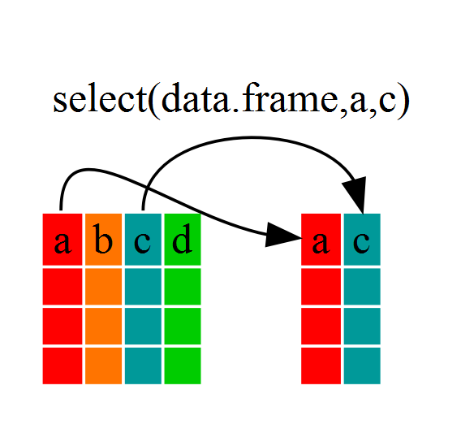

## Seleccionar los datos médicos

**Código**

```r
pacientes_centro_profesional <- select(datos_medicos, Centro, Profesional, "0111")
pacientes_centro_profesional
```

```
# A tibble: 248 × 3
   Centro     Profesional `0111`
   <chr>      <chr>        <dbl>
 1 El Cain    Juana Susse      6
 2 El Cain    Juana Susse      6
 3 El Cain    Juana Susse     NA
 4 Maquinchao Juana Susse     NA
 5 Maquinchao Juana Susse     NA
 6 Maquinchao Juana Susse      8
 7 El Cain    Juana Susse      6
 8 El Cain    Juana Susse      5
 9 El Cain    Juana Susse     NA
10 El Cain    Juana Susse     NA
# ℹ 238 more rows
```

## Seleccionar los datos médicos utilizando “:”

**Código**

```r
pacientes_centro_profesional <- select(datos_medicos, Profesional:"0101")
pacientes_centro_profesional
```

```
# A tibble: 248 × 4
   Profesional Fecha      Centro     `0101`
   <chr>       <chr>      <chr>       <dbl>
 1 Juana Susse 01/07/2021 El Cain         5
 2 Juana Susse 02/07/2021 El Cain         6
 3 Juana Susse 03/07/2021 El Cain        NA
 4 Juana Susse 04/07/2021 Maquinchao     NA
 5 Juana Susse 05/07/2021 Maquinchao     NA
 6 Juana Susse 06/07/2021 Maquinchao      8
 7 Juana Susse 07/07/2021 El Cain         6
 8 Juana Susse 08/07/2021 El Cain         5
 9 Juana Susse 09/07/2021 El Cain        NA
10 Juana Susse 10/07/2021 El Cain        NA
# ℹ 238 more rows
```

**Código**

```r
pacientes_centro_profesional2 <- select(datos_medicos, where(is.numeric))
pacientes_centro_profesional2
```

```
# A tibble: 248 × 37
   `0101` `0104` `0107` `0108` `0109` `0111` `0112` `0116` `0216` `0217` `0218`
    <dbl>  <dbl>  <dbl>  <dbl>  <dbl>  <dbl>  <dbl>  <dbl>  <dbl>  <dbl>  <dbl>
 1      5      1     NA     NA     NA      6     NA     NA     NA     NA     NA
 2      6     NA     NA     NA     NA      6     NA     NA      1     NA     NA
 3     NA     NA     NA     NA     NA     NA     NA     NA     NA     NA     NA
 4     NA     NA     NA     NA     NA     NA     NA     NA     NA     NA     NA
 5     NA     NA     NA     NA     NA     NA     NA     NA     NA     NA     NA
 6      8     NA     NA     NA     NA      8     NA     NA     NA     NA     NA
 7      6     NA     NA     NA     NA      6     NA     NA     NA     NA     NA
 8      5     NA     NA     NA     NA      5     NA     NA     NA     NA     NA
 9     NA     NA     NA     NA     NA     NA     NA     NA     NA     NA     NA
10     NA     NA     NA     NA     NA     NA     NA     NA     NA     NA     NA
# ℹ 238 more rows
# ℹ 26 more variables: `0219` <dbl>, `0220` <dbl>, `0223` <dbl>, `0303` <dbl>,
#   `0305` <dbl>, `0501` <dbl>, `0502` <dbl>, `0503` <dbl>, `0504` <dbl>,
#   `0505` <dbl>, `0506` <dbl>, `0507` <dbl>, `0508` <dbl>, `0509` <dbl>,
#   `0701` <dbl>, `0702` <dbl>, `0707` <dbl>, `0802` <dbl>, `0901` <dbl>,
#   `1001` <dbl>, `1007` <dbl>, `1008` <dbl>, `1015` <dbl>, `1016` <dbl>,
#   `1026` <dbl>, `1028` <dbl>
```

## Criterios de selección

Funciones auxiliares de selección.

> - `everything()`: Selecciona todas las variables
> - `last_col()`: Selecciona la última variable
> - `group_cols()` Selecciona grupo de columnas
> - `starts_with()` Matchea las columnas que comienzan con un prefijo.
> - `ends_with()` Matchea las columnas que terminan con un sufijo.
> - `starts_with()` Matchea las columnas que comienzan con un prefijo.
> - `contains()` contiene un string.
> - `matches()` Expresion regular.

## Utilizar el verbo filter()

En este caso entonces

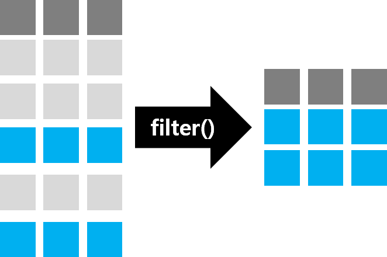

## Filtrar por Profesional

**Código**

```r
filter(pacientes_centro_profesional,
       Profesional == "Carlos Pica")
```

```
# A tibble: 31 × 4
   Profesional Fecha      Centro           `0101`
   <chr>       <chr>      <chr>             <dbl>
 1 Carlos Pica 01/07/2021 Maquinchao            4
 2 Carlos Pica 02/07/2021 Maquinchao            3
 3 Carlos Pica 03/07/2021 Maquinchao           NA
 4 Carlos Pica 04/07/2021 Aguada de Guerra     NA
 5 Carlos Pica 05/07/2021 Aguada de Guerra     NA
 6 Carlos Pica 06/07/2021 Aguada de Guerra      3
 7 Carlos Pica 07/07/2021 Maquinchao            3
 8 Carlos Pica 08/07/2021 Maquinchao            4
 9 Carlos Pica 09/07/2021 Maquinchao           NA
10 Carlos Pica 10/07/2021 Maquinchao           NA
# ℹ 21 more rows
```

## Filtrar con más de un criterio

**Código**

```r
filter(pacientes_centro_profesional,
       Profesional == "Carlos Pica" & Centro == "Maquinchao")
```

```
# A tibble: 20 × 4
   Profesional Fecha      Centro     `0101`
   <chr>       <chr>      <chr>       <dbl>
 1 Carlos Pica 01/07/2021 Maquinchao      4
 2 Carlos Pica 02/07/2021 Maquinchao      3
 3 Carlos Pica 03/07/2021 Maquinchao     NA
 4 Carlos Pica 07/07/2021 Maquinchao      3
 5 Carlos Pica 08/07/2021 Maquinchao      4
 6 Carlos Pica 09/07/2021 Maquinchao     NA
 7 Carlos Pica 10/07/2021 Maquinchao     NA
 8 Carlos Pica 14/07/2021 Maquinchao      3
 9 Carlos Pica 15/07/2021 Maquinchao      3
10 Carlos Pica 16/07/2021 Maquinchao      4
11 Carlos Pica 17/07/2021 Maquinchao     NA
12 Carlos Pica 18/07/2021 Maquinchao     NA
13 Carlos Pica 21/07/2021 Maquinchao      3
14 Carlos Pica 22/07/2021 Maquinchao      3
15 Carlos Pica 23/07/2021 Maquinchao      4
16 Carlos Pica 24/07/2021 Maquinchao     NA
17 Carlos Pica 25/07/2021 Maquinchao     NA
18 Carlos Pica 28/07/2021 Maquinchao      4
19 Carlos Pica 29/07/2021 Maquinchao      3
20 Carlos Pica 30/07/2021 Maquinchao      4
```

## Mutate y rename

*mutate* realiza modificaciones y cálculos sobre las columnas.

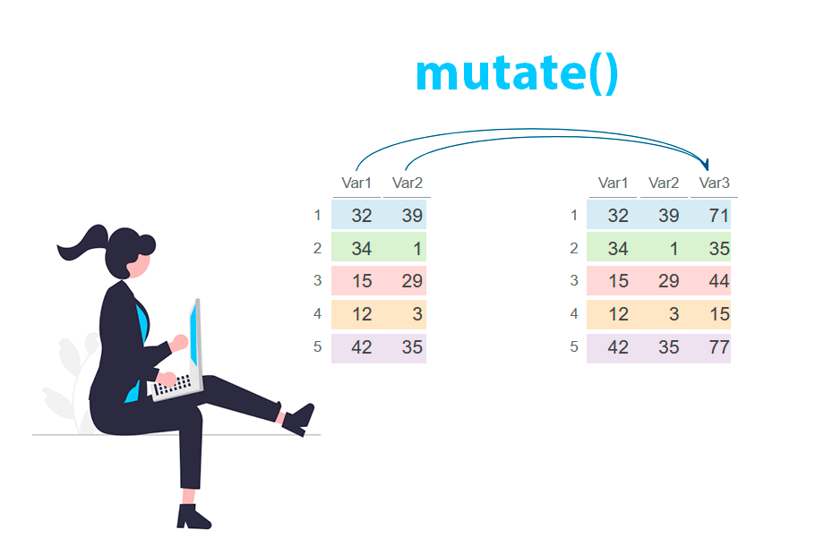

## Renombrar una columna de la tabla de datos

En este caso la prestación “0111” es indicador del número de pacientes.

**Código**

```r
datos_medicos_ren  <- rename(datos_medicos,
                             Pacientes = "0111")
datos_medicos_ren
```

```
# A tibble: 248 × 73
   Profesional Fecha     Centro `0101` `0103` `0104` `0107` `0108` `0109` `0110`
   <chr>       <chr>     <chr>   <dbl> <lgl>   <dbl>  <dbl>  <dbl>  <dbl> <lgl>
 1 Juana Susse 01/07/20… El Ca…      5 NA          1     NA     NA     NA NA
 2 Juana Susse 02/07/20… El Ca…      6 NA         NA     NA     NA     NA NA
 3 Juana Susse 03/07/20… El Ca…     NA NA         NA     NA     NA     NA NA
 4 Juana Susse 04/07/20… Maqui…     NA NA         NA     NA     NA     NA NA
 5 Juana Susse 05/07/20… Maqui…     NA NA         NA     NA     NA     NA NA
 6 Juana Susse 06/07/20… Maqui…      8 NA         NA     NA     NA     NA NA
 7 Juana Susse 07/07/20… El Ca…      6 NA         NA     NA     NA     NA NA
 8 Juana Susse 08/07/20… El Ca…      5 NA         NA     NA     NA     NA NA
 9 Juana Susse 09/07/20… El Ca…     NA NA         NA     NA     NA     NA NA
10 Juana Susse 10/07/20… El Ca…     NA NA         NA     NA     NA     NA NA
# ℹ 238 more rows
# ℹ 63 more variables: Pacientes <dbl>, `0112` <dbl>, `0114` <lgl>,
#   `0116` <dbl>, `0118` <lgl>, `0216` <dbl>, `0217` <dbl>, `0218` <dbl>,
#   `0219` <dbl>, `0220` <dbl>, `0221` <lgl>, `0222` <lgl>, `0223` <dbl>,
#   `0302` <lgl>, `0303` <dbl>, `0304` <lgl>, `0305` <dbl>, `0403` <lgl>,
#   `0404` <lgl>, `0411` <lgl>, `0501` <dbl>, `0502` <dbl>, `0503` <dbl>,
#   `0504` <dbl>, `0505` <dbl>, `0506` <dbl>, `0507` <dbl>, `0508` <dbl>, …
```

# Tuberías o *pipes*

Se pueden encadenar estos verbos entre sí.

## Operador |>

Uso del operador |> (pipe).

**Código**

```r
datos_medicos |>  select(Centro, Profesional, "0111") |>
  filter( Profesional == "Carlos Pica" & Centro == "Maquinchao")
```

```
# A tibble: 20 × 3
   Centro     Profesional `0111`
   <chr>      <chr>        <dbl>
 1 Maquinchao Carlos Pica      6
 2 Maquinchao Carlos Pica      6
 3 Maquinchao Carlos Pica     NA
 4 Maquinchao Carlos Pica      6
 5 Maquinchao Carlos Pica      6
 6 Maquinchao Carlos Pica     NA
 7 Maquinchao Carlos Pica     NA
 8 Maquinchao Carlos Pica      6
 9 Maquinchao Carlos Pica      6
10 Maquinchao Carlos Pica      6
11 Maquinchao Carlos Pica     NA
12 Maquinchao Carlos Pica     NA
13 Maquinchao Carlos Pica      6
14 Maquinchao Carlos Pica      6
15 Maquinchao Carlos Pica      6
16 Maquinchao Carlos Pica     NA
17 Maquinchao Carlos Pica     NA
18 Maquinchao Carlos Pica      6
19 Maquinchao Carlos Pica      6
20 Maquinchao Carlos Pica      6
```

## Ventajas

> - Alternativa a las funciones anidadas
> - Mejora la legibilidad
> - Ahorra espacio en memoria

## Resumiendo la información: Aplicando el verbo summarize

El verbo summarize() va acompañado de la función “grouped_by”

**Código**

```r
datos_medicos_ren |>  group_by(Centro) |>
  summarize(N = n(),
            Total = sum(Pacientes, na.rm = T)
            )
```

```
# A tibble: 8 × 3
  Centro               N Total
  <chr>            <int> <dbl>
1 Aguada de Guerra    42   207
2 Balsa Las Perlas    31    75
3 Don Bosco           31    94
4 El Cain             40   117
5 El Cuy              31    73
6 Ing.Jacobacci       31    61
7 Maquinchao          31   138
8 María Magdalena     11    25
```

## Resumen condicional y datos faltantes

Sumar con presencia de datos faltante o NA

**Código**

```r
datos_medicos |>
  group_by(Centro) |>
  summarise_if(is.numeric,sum, na.rm =TRUE)
```

```
# A tibble: 8 × 38
  Centro   `0101` `0104` `0107` `0108` `0109` `0111` `0112` `0116` `0216` `0217`
  <chr>     <dbl>  <dbl>  <dbl>  <dbl>  <dbl>  <dbl>  <dbl>  <dbl>  <dbl>  <dbl>
1 Aguada …    200     83      0     37     28    207    270      0      9      9
2 Balsa L…     75     18      3      0      0     75     60      1      0      0
3 Don Bos…     51     23      6      1      0     94      0      0      1      0
4 El Cain     114     16      0      0      0    117      0      0      6     10
5 El Cuy       38     27      0     24      0     73      0      0      6      0
6 Ing.Jac…     19     15      0      2      2     61      0      0      1      4
7 Maquinc…    101     53      0      0     32    138     78      0     24     22
8 María M…     24      6      0      0      0     25      0      0      2      2
# ℹ 27 more variables: `0218` <dbl>, `0219` <dbl>, `0220` <dbl>, `0223` <dbl>,
#   `0303` <dbl>, `0305` <dbl>, `0501` <dbl>, `0502` <dbl>, `0503` <dbl>,
#   `0504` <dbl>, `0505` <dbl>, `0506` <dbl>, `0507` <dbl>, `0508` <dbl>,
#   `0509` <dbl>, `0701` <dbl>, `0702` <dbl>, `0707` <dbl>, `0802` <dbl>,
#   `0901` <dbl>, `1001` <dbl>, `1007` <dbl>, `1008` <dbl>, `1015` <dbl>,
#   `1016` <dbl>, `1026` <dbl>, `1028` <dbl>
```

## Resumiendo información con más de un criterio

**Código**

```r
datos_medicos_ren |>
  group_by(Centro, Profesional) |>
  summarize(N = n(),
            Total = sum(Pacientes, na.rm = T)
)
```

```
# A tibble: 11 × 4
# Groups:   Centro [8]
   Centro           Profesional        N Total
   <chr>            <chr>          <int> <dbl>
 1 Aguada de Guerra Carlos Pica       11    42
 2 Aguada de Guerra Pedro Bianchi     31   165
 3 Balsa Las Perlas Silvia Laike      31    75
 4 Don Bosco        Alejandra Soto    31    94
 5 El Cain          Adriel Santos     20    37
 6 El Cain          Juana Susse       20    80
 7 El Cuy           Charol Verdi      31    73
 8 Ing.Jacobacci    Vera Saez         31    61
 9 Maquinchao       Carlos Pica       20    78
10 Maquinchao       Juana Susse       11    60
11 María Magdalena  Adriel Santos     11    25
```

## Total de pacientes atendidos por centro

**Código**

```r
datos_medicos_ren |>
  select(c("Centro","Pacientes"))  |>
  group_by(Centro)  |>
  summarise_if(is.numeric,sum, na.rm=TRUE)
```

```
# A tibble: 8 × 2
  Centro           Pacientes
  <chr>                <dbl>
1 Aguada de Guerra       207
2 Balsa Las Perlas        75
3 Don Bosco               94
4 El Cain                117
5 El Cuy                  73
6 Ing.Jacobacci           61
7 Maquinchao             138
8 María Magdalena         25
```

## Configuración del Pipe Nativo `|>`

Sustituir `%>%` por `|>` al usar el atajo de teclado en **RStudio**:

### Pasos de configuración

1. Ir a **Tools** $\rightarrow$ **Global Options…**
2. En el panel izquierdo, seleccionar **Code**.
3. En la pestaña **Editing**, activar:  
   `[x] Use native pipe operator, |> (requires R 4.1+)`
4. Confirmar con **Apply** y **OK**.

### Atajo de teclado

- **Windows / Linux:**  
  `Ctrl` + `Shift` + `M`
- **Mac:**  
  `Cmd` + `Shift` + `M`

**NotaRequisito**

Requiere versión de **R $\ge$ 4.1.0**.

## Presentación en tablas

**Código**

```r
library(kableExtra)
datos_med <-  datos_medicos_ren |> select(c("Centro","Pacientes")) |>  group_by(Centro) |>  summarise(tota_pacientes=sum(Pacientes,na.rm=TRUE))
datos_med |>   kable(booktabs = T) |>   kable_styling() |> row_spec(which.max(datos_med$tota_pacientes), bold = T, color = "white", background = "red")
```

| Centro | tota_pacientes |
| --- | --- |
| Aguada de Guerra | 207 |
| Balsa Las Perlas | 75 |
| Don Bosco | 94 |
| El Cain | 117 |
| El Cuy | 73 |
| Ing.Jacobacci | 61 |
| Maquinchao | 138 |
| María Magdalena | 25 |

## Otras tablas

**Código**

```r
library(kableExtra)
datos_medicos_ren |>
  select(c("Centro","Pacientes", "Profesional")) |>  group_by(Centro) |>  summarise(total_pacientes=sum(Pacientes,na.rm=TRUE))
```

```
# A tibble: 8 × 2
  Centro           total_pacientes
  <chr>                      <dbl>
1 Aguada de Guerra             207
2 Balsa Las Perlas              75
3 Don Bosco                     94
4 El Cain                      117
5 El Cuy                        73
6 Ing.Jacobacci                 61
7 Maquinchao                   138
8 María Magdalena               25
```

## Renombrar columnas: rename

**Código**

```r
datos_medicos_resumen <- datos_medicos |>
  group_by(Centro)  |>
  summarise_if(is.numeric,sum, na.rm=TRUE)
datos_medicos_resumen_r <- datos_medicos_resumen   |>
  rename(Pacientes = "0111")
datos_medicos_resumen_r
```

```
# A tibble: 8 × 38
  Centro       `0101` `0104` `0107` `0108` `0109` Pacientes `0112` `0116` `0216`
  <chr>         <dbl>  <dbl>  <dbl>  <dbl>  <dbl>     <dbl>  <dbl>  <dbl>  <dbl>
1 Aguada de G…    200     83      0     37     28       207    270      0      9
2 Balsa Las P…     75     18      3      0      0        75     60      1      0
3 Don Bosco        51     23      6      1      0        94      0      0      1
4 El Cain         114     16      0      0      0       117      0      0      6
5 El Cuy           38     27      0     24      0        73      0      0      6
6 Ing.Jacobac…     19     15      0      2      2        61      0      0      1
7 Maquinchao      101     53      0      0     32       138     78      0     24
8 María Magda…     24      6      0      0      0        25      0      0      2
# ℹ 28 more variables: `0217` <dbl>, `0218` <dbl>, `0219` <dbl>, `0220` <dbl>,
#   `0223` <dbl>, `0303` <dbl>, `0305` <dbl>, `0501` <dbl>, `0502` <dbl>,
#   `0503` <dbl>, `0504` <dbl>, `0505` <dbl>, `0506` <dbl>, `0507` <dbl>,
#   `0508` <dbl>, `0509` <dbl>, `0701` <dbl>, `0702` <dbl>, `0707` <dbl>,
#   `0802` <dbl>, `0901` <dbl>, `1001` <dbl>, `1007` <dbl>, `1008` <dbl>,
#   `1015` <dbl>, `1016` <dbl>, `1026` <dbl>, `1028` <dbl>
```

## Acción de Mutate

**Código**

```r
datos_medicos_resumen_r |>
  select("Pacientes")  |>
  mutate(Pacientes_dia = Pacientes/20)
```

```
# A tibble: 8 × 2
  Pacientes Pacientes_dia
      <dbl>         <dbl>
1       207         10.4
2        75          3.75
3        94          4.7
4       117          5.85
5        73          3.65
6        61          3.05
7       138          6.9
8        25          1.25
```

# Tidy datos

[figure not shown]

Transformar la estructura de los datos.

## Características de los “tidy” datos

> 1. Las filas, llamadas casos u observaciones, se refieren a un tipo de cosa específico, único y similar, por ejemplo, centros.
> 2. Las columnas, llamadas variables, tienen el mismo tipo de valor registrado para cada fila. Por ejemplo, Cantidad da el número de prestaciones; prestación hace referencia a la práctica médica.

## Tablas a lo largo y a lo ancho

**Código**

```r
tot_centro_pres <- datos_medicos |>
  group_by(Centro)  |>
  summarise_if(is.numeric, sum, na.rm = TRUE)
tot_centro_pres
```

```
# A tibble: 8 × 38
  Centro   `0101` `0104` `0107` `0108` `0109` `0111` `0112` `0116` `0216` `0217`
  <chr>     <dbl>  <dbl>  <dbl>  <dbl>  <dbl>  <dbl>  <dbl>  <dbl>  <dbl>  <dbl>
1 Aguada …    200     83      0     37     28    207    270      0      9      9
2 Balsa L…     75     18      3      0      0     75     60      1      0      0
3 Don Bos…     51     23      6      1      0     94      0      0      1      0
4 El Cain     114     16      0      0      0    117      0      0      6     10
5 El Cuy       38     27      0     24      0     73      0      0      6      0
6 Ing.Jac…     19     15      0      2      2     61      0      0      1      4
7 Maquinc…    101     53      0      0     32    138     78      0     24     22
8 María M…     24      6      0      0      0     25      0      0      2      2
# ℹ 27 more variables: `0218` <dbl>, `0219` <dbl>, `0220` <dbl>, `0223` <dbl>,
#   `0303` <dbl>, `0305` <dbl>, `0501` <dbl>, `0502` <dbl>, `0503` <dbl>,
#   `0504` <dbl>, `0505` <dbl>, `0506` <dbl>, `0507` <dbl>, `0508` <dbl>,
#   `0509` <dbl>, `0701` <dbl>, `0702` <dbl>, `0707` <dbl>, `0802` <dbl>,
#   `0901` <dbl>, `1001` <dbl>, `1007` <dbl>, `1008` <dbl>, `1015` <dbl>,
#   `1016` <dbl>, `1026` <dbl>, `1028` <dbl>
```

## Utilizando la función pivot_longer

**Código**

```r
library(tidyr)
tot_centro_pres_long = tot_centro_pres |>
 pivot_longer(!Centro, names_to = "Presta", values_to = "Cantidad")
tot_centro_pres_long
```

```
# A tibble: 296 × 3
   Centro           Presta Cantidad
   <chr>            <chr>     <dbl>
 1 Aguada de Guerra 0101        200
 2 Aguada de Guerra 0104         83
 3 Aguada de Guerra 0107          0
 4 Aguada de Guerra 0108         37
 5 Aguada de Guerra 0109         28
 6 Aguada de Guerra 0111        207
 7 Aguada de Guerra 0112        270
 8 Aguada de Guerra 0116          0
 9 Aguada de Guerra 0216          9
10 Aguada de Guerra 0217          9
# ℹ 286 more rows
```

## Formato long vs. wide

Existen motivos para preferir el formato *long* al formato *wide*.

> - Es una forma más eficiente para el almacenamiento y recuperación de los datos.
> - Es más conveniente para el análisis de datos.
> - Es más escalable, la adición de una segunda variable aporta otra columna.

# Manejo de múltiples tablas

[figure not shown]

## left_join()

Se devuelven todas las filas de la primera tabla, independientemente de si hay una coincidencia en la segunda tabla.

## inner_join()

Hacer coincidir las filas de la tabla 1 con las filas de la tabla 2 que tienen los valores correspondientes para la columna de ambas tablas. Esto se logra con la función inner_join ().

## Tablas de códigos

**Código**

```r
codigos <-  readODS::read_ods("datos/Codigos.ods")
glimpse(codigos)
```

```
Rows: 69
Columns: 3
$ Codigos     <chr> "0101", "0103", "0104", "0107", "0108", "0109", "0110", "0…
$ Descripcion <chr> "Consulta", "Atencion Escolar", "Urgencias", "Pacientes Es…
$ Capitulo    <chr> "Consultas", "Consultas", "Consultas", "Consultas", "Consu…
```

## Cruzar las tablas mediante una columna

**Código**

```r
tot_centro_pres_long_rename <-  tot_centro_pres_long %>% rename(Codigos=Presta)
tot_centro_pres_long_join <-  inner_join(tot_centro_pres_long_rename, codigos, by = "Codigos")
tot_centro_pres_long_join
```

```
# A tibble: 296 × 5
   Centro           Codigos Cantidad Descripcion           Capitulo
   <chr>            <chr>      <dbl> <chr>                 <chr>
 1 Aguada de Guerra 0101         200 Consulta              Consultas
 2 Aguada de Guerra 0104          83 Urgencias             Consultas
 3 Aguada de Guerra 0107           0 Pacientes Especiales  Consultas
 4 Aguada de Guerra 0108          37 Reuniones             Consultas
 5 Aguada de Guerra 0109          28 Certificados          Consultas
 6 Aguada de Guerra 0111         207 Bioseguridad          Consultas
 7 Aguada de Guerra 0112         270 Administración        Consultas
 8 Aguada de Guerra 0116           0 Embarazadas           Consultas
 9 Aguada de Guerra 0216           9 Restauracion simple   Operatoria
10 Aguada de Guerra 0217           9 Restauracion compleja Operatoria
# ℹ 286 more rows
```

## Probar que es igual

Es muy importante chequear que la tabla original tiene el mismo número de filas que la tabla final.

**Código**

```r
all.equal(nrow(tot_centro_pres_long_join), nrow(tot_centro_pres_long_rename))
```

```
[1] TRUE
```

## Concatenar con gráficos

**Código**

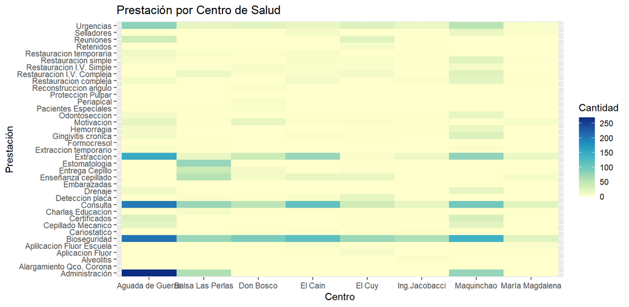

```r
tot_centro_pres_long_join |>  ggplot(aes(x=Centro, y = Descripcion)) +
  geom_tile(aes(fill=Cantidad)) +  scale_fill_distiller(palette = "YlGnBu", direction = 1)  +
  labs(title = "Prestación por Centro de Salud", y = "Prestación")
```

# Datos con fechas

Es difícil trabajar con fechas en R! librería lubridate()

## Retomando los datos médicos

**Código**

```r
library(lubridate)
datos_medicos
```

```
# A tibble: 248 × 73
   Profesional Fecha     Centro `0101` `0103` `0104` `0107` `0108` `0109` `0110`
   <chr>       <chr>     <chr>   <dbl> <lgl>   <dbl>  <dbl>  <dbl>  <dbl> <lgl>
 1 Juana Susse 01/07/20… El Ca…      5 NA          1     NA     NA     NA NA
 2 Juana Susse 02/07/20… El Ca…      6 NA         NA     NA     NA     NA NA
 3 Juana Susse 03/07/20… El Ca…     NA NA         NA     NA     NA     NA NA
 4 Juana Susse 04/07/20… Maqui…     NA NA         NA     NA     NA     NA NA
 5 Juana Susse 05/07/20… Maqui…     NA NA         NA     NA     NA     NA NA
 6 Juana Susse 06/07/20… Maqui…      8 NA         NA     NA     NA     NA NA
 7 Juana Susse 07/07/20… El Ca…      6 NA         NA     NA     NA     NA NA
 8 Juana Susse 08/07/20… El Ca…      5 NA         NA     NA     NA     NA NA
 9 Juana Susse 09/07/20… El Ca…     NA NA         NA     NA     NA     NA NA
10 Juana Susse 10/07/20… El Ca…     NA NA         NA     NA     NA     NA NA
# ℹ 238 more rows
# ℹ 63 more variables: `0111` <dbl>, `0112` <dbl>, `0114` <lgl>, `0116` <dbl>,
#   `0118` <lgl>, `0216` <dbl>, `0217` <dbl>, `0218` <dbl>, `0219` <dbl>,
#   `0220` <dbl>, `0221` <lgl>, `0222` <lgl>, `0223` <dbl>, `0302` <lgl>,
#   `0303` <dbl>, `0304` <lgl>, `0305` <dbl>, `0403` <lgl>, `0404` <lgl>,
#   `0411` <lgl>, `0501` <dbl>, `0502` <dbl>, `0503` <dbl>, `0504` <dbl>,
#   `0505` <dbl>, `0506` <dbl>, `0507` <dbl>, `0508` <dbl>, `0509` <dbl>, …
```

## Calcular la prestación por fecha

**Código**

```r
tot_fecha_pres <-  datos_medicos |>   group_by(Fecha)  |>
  summarise_if(is.numeric, sum, na.rm = TRUE)
tot_fecha_pres_longer = tot_fecha_pres  %>%
  pivot_longer(!Fecha, names_to = "Prestacion", values_to = "Cantidad")
tot_fecha_pres_longer
```

```
# A tibble: 1,147 × 3
   Fecha      Prestacion Cantidad
   <chr>      <chr>         <dbl>
 1 01/07/2021 0101             23
 2 01/07/2021 0104             14
 3 01/07/2021 0107              1
 4 01/07/2021 0108             13
 5 01/07/2021 0109              3
 6 01/07/2021 0111             32
 7 01/07/2021 0112             21
 8 01/07/2021 0116              0
 9 01/07/2021 0216              2
10 01/07/2021 0217              1
# ℹ 1,137 more rows
```

## Utilizar fechas

**Código**

```r
tot_fecha_pres_longer <- tot_fecha_pres_longer |>  mutate(diames = as.Date(Fecha, '%d/%m/%Y'))
tot_fecha_pres_longer
```

```
# A tibble: 1,147 × 4
   Fecha      Prestacion Cantidad diames
   <chr>      <chr>         <dbl> <date>
 1 01/07/2021 0101             23 2021-07-01
 2 01/07/2021 0104             14 2021-07-01
 3 01/07/2021 0107              1 2021-07-01
 4 01/07/2021 0108             13 2021-07-01
 5 01/07/2021 0109              3 2021-07-01
 6 01/07/2021 0111             32 2021-07-01
 7 01/07/2021 0112             21 2021-07-01
 8 01/07/2021 0116              0 2021-07-01
 9 01/07/2021 0216              2 2021-07-01
10 01/07/2021 0217              1 2021-07-01
# ℹ 1,137 more rows
```

## Extraer el día de mes

**Código**

```r
tot_fecha_pres_longer2  <- tot_fecha_pres_longer |>  mutate(dia=mday(diames))
tot_fecha_pres_longer2
```

```
# A tibble: 1,147 × 5
   Fecha      Prestacion Cantidad diames       dia
   <chr>      <chr>         <dbl> <date>     <int>
 1 01/07/2021 0101             23 2021-07-01     1
 2 01/07/2021 0104             14 2021-07-01     1
 3 01/07/2021 0107              1 2021-07-01     1
 4 01/07/2021 0108             13 2021-07-01     1
 5 01/07/2021 0109              3 2021-07-01     1
 6 01/07/2021 0111             32 2021-07-01     1
 7 01/07/2021 0112             21 2021-07-01     1
 8 01/07/2021 0116              0 2021-07-01     1
 9 01/07/2021 0216              2 2021-07-01     1
10 01/07/2021 0217              1 2021-07-01     1
# ℹ 1,137 more rows
```

## Día de la semana

**Código**

```r
tot_fecha_pres_longer2 <- tot_fecha_pres_longer2 |>  mutate(diasemana=wday(diames, label = T))
tot_fecha_pres_longer2
```

```
# A tibble: 1,147 × 6
   Fecha      Prestacion Cantidad diames       dia diasemana
   <chr>      <chr>         <dbl> <date>     <int> <ord>
 1 01/07/2021 0101             23 2021-07-01     1 "jue\\."
 2 01/07/2021 0104             14 2021-07-01     1 "jue\\."
 3 01/07/2021 0107              1 2021-07-01     1 "jue\\."
 4 01/07/2021 0108             13 2021-07-01     1 "jue\\."
 5 01/07/2021 0109              3 2021-07-01     1 "jue\\."
 6 01/07/2021 0111             32 2021-07-01     1 "jue\\."
 7 01/07/2021 0112             21 2021-07-01     1 "jue\\."
 8 01/07/2021 0116              0 2021-07-01     1 "jue\\."
 9 01/07/2021 0216              2 2021-07-01     1 "jue\\."
10 01/07/2021 0217              1 2021-07-01     1 "jue\\."
# ℹ 1,137 more rows
```

## Día del año

**Código**

```r
tot_fecha_pres_longer2 <- tot_fecha_pres_longer2 |>  mutate(diasanio=yday(diames))
tot_fecha_pres_longer2
```

```
# A tibble: 1,147 × 7
   Fecha      Prestacion Cantidad diames       dia diasemana diasanio
   <chr>      <chr>         <dbl> <date>     <int> <ord>        <dbl>
 1 01/07/2021 0101             23 2021-07-01     1 "jue\\."       182
 2 01/07/2021 0104             14 2021-07-01     1 "jue\\."       182
 3 01/07/2021 0107              1 2021-07-01     1 "jue\\."       182
 4 01/07/2021 0108             13 2021-07-01     1 "jue\\."       182
 5 01/07/2021 0109              3 2021-07-01     1 "jue\\."       182
 6 01/07/2021 0111             32 2021-07-01     1 "jue\\."       182
 7 01/07/2021 0112             21 2021-07-01     1 "jue\\."       182
 8 01/07/2021 0116              0 2021-07-01     1 "jue\\."       182
 9 01/07/2021 0216              2 2021-07-01     1 "jue\\."       182
10 01/07/2021 0217              1 2021-07-01     1 "jue\\."       182
# ℹ 1,137 more rows
```

## Sumar prestaciones por día de la semana

**Código**

```r
tot_fecha_pres_longer2  |>  group_by(diasemana) |>   filter(between(diasemana,"lun", "vie")) |>  summarise(Prestacion_diasemana = sum(Cantidad))
```

```
# A tibble: 4 × 2
  diasemana Prestacion_diasemana
  <ord>                    <dbl>
1 "lun\\."                   656
2 "mar\\."                   671
3 "mié\\."                   731
4 "sáb\\."                     7
```

# Estructuras de datos

Dos importantes: **dataframes** y listas

[figure not shown]

Data Frames y tibbles

## Marco de datos o lista??

Creo un marco de datos

**Código**

```r
dfm <- data.frame(Frutas = c("banana", "pera", "cereza"))
dfm$y <- matrix(1:9, nrow = 3)
dfm$z <- data.frame(a = 3:1, b = letters[1:3], stringsAsFactors = FALSE)
str(dfm)
```

```
'data.frame':   3 obs. of  3 variables:
 $ Frutas: chr  "banana" "pera" "cereza"
 $ y     : int [1:3, 1:3] 1 2 3 4 5 6 7 8 9
 $ z     :'data.frame': 3 obs. of  2 variables:
  ..$ a: int  3 2 1
  ..$ b: chr  "a" "b" "c"
```

A diferencia de una lista normal, un marco de datos tiene una restricción adicional: la longitud de cada uno de sus vectores debe ser la misma.

## Qué sucede con los tibbles

**Código**

```r
dfm <- tibble(
  Frutas = c("banana", "pera", "cereza")
)
dfm$y <- matrix(1:9, nrow = 3)
dfm$z <- data.frame(a = 3:1, b = letters[1:3], stringsAsFactors = FALSE)

str(dfm)
```

```
tibble [3 × 3] (S3: tbl_df/tbl/data.frame)
 $ Frutas: chr [1:3] "banana" "pera" "cereza"
 $ y     : int [1:3, 1:3] 1 2 3 4 5 6 7 8 9
 $ z     :'data.frame': 3 obs. of  2 variables:
  ..$ a: int [1:3] 3 2 1
  ..$ b: chr [1:3] "a" "b" "c"
```

## Qué son los tibbles?

- Una reinvención moderna del marco de datos, están diseñados para ser reemplazos directos de los marcos de datos. Una forma concisa de definir los tibbles de acuerdo al autor “son perezosos y hoscos: hacen menos y se quejan más”.
- Tibbles son proporcionados por el paquete tibble y comparten la misma estructura que los marcos de datos. La única diferencia es que el vector de clase es más largo e incluye tbl_df. Esto permite que tibbles se comporte de manera diferente.

## Diferencias

Otra diferencia es que los tibbles nunca fuerzan (coarce) su entrada ):

**Código**

```r
df1 <- data.frame(
  x = 1:3,
  y = c("a", "b", "c")
)
str(df1)
```

```
'data.frame':   3 obs. of  2 variables:
 $ x: int  1 2 3
 $ y: chr  "a" "b" "c"
```

**Código**

```r
df2 <- tibble(
  x = 1:3,
  y = c("a", "b", "c")
)
str(df2)
```

```
tibble [3 × 2] (S3: tbl_df/tbl/data.frame)
 $ x: int [1:3] 1 2 3
 $ y: chr [1:3] "a" "b" "c"
```

## Diferencias

Los data frames transforman sintácticamente los nombres, los tibbles no.

**Código**

```r
names(data.frame(`1` = 1))
```

```
[1] "X1"
```

**Código**

```
#> [1] "X1"
```

```r
names(tibble(`1` = 1))
```

```
[1] "1"
```

**Código**

```
#> [1] "1"
```

## Diferencias en el “reciclado” del vector

**Código**

```r
data.frame(x = 1:4, y = 1:2)
```

```
  x y
1 1 1
2 2 2
3 3 1
4 4 2
```

**Código**

```
#>   x y
#> 1 1 1
#> 2 2 2
#> 3 3 1
#> 4 4 2
```

## Diferencias en el “reciclado” del vector

**Código**

```r
tibble(x = 1:4, y = 1)
```

```
# A tibble: 4 × 2
      x     y
  <int> <dbl>
1     1     1
2     2     1
3     3     1
4     4     1
```

**Código**

```
#> # A tibble: 4 x 2
#>       x     y
#>   <int> <dbl>
#> 1     1     1
#> 2     2     1
#> 3     3     1
#> 4     4     1
```

```r
tibble(x = 1:4, y = 1:2)
```

```
Error in `tibble()`:
! Tibble columns must have compatible sizes.
• Size 4: Existing data.
• Size 2: Column `y`.
ℹ Only values of size one are recycled.
```

**Código**

```
#> Error: Tibble columns must have compatible sizes.
#> * Size 4: Existing data.
#> * Size 2: Column `y`.
#> ℹ Only values of size one are recycled.
```

## Diferencia más importante

tibble () le permite hacer referencia a las variables creadas durante la construcción:

**Código**

```r
tibble(
  x = 1:3,
  y = x * 2)
```

```
# A tibble: 3 × 2
      x     y
  <int> <dbl>
1     1     2
2     2     4
3     3     6
```

# Importar datos

Importar y Exportar datos

[figure not shown]

Data Frames y tibbles

## Distintas opciones

La manera de importar datos más común es:

- desde un archivo separado por comas.
- desde un archivo excel.
- desde una hoja de cálculo en googledrive.

## Importar datos separados por comas

**Código**

```r
library(readr)
datos_ovejas <- read.csv2("datos/datos_ovejas.csv")
```

## Importar datos desde excel

**Código**

```r
library(readxl)
datos_morfometricos <- read_excel("datos/Datos_morfometricos_final.xlsx")
glimpse(datos_morfometricos)
```

```
Rows: 1,210
Columns: 12
$ Tratamiento                          <chr> "PA", NA, NA, NA, NA, NA, NA, NA,…
$ `fecha nac`                          <chr> "42312", "42313", "42312", "42313…
$ caravana                             <dbl> 4650, 4651, 4652, 4653, 4654, 465…
$ `P. Nac`                             <dbl> 3.200, 3.960, 3.025, 4.300, 3.150…
$ sexo                                 <chr> "H", "M", "H", "M", "H", "M", "H"…
$ `altura+3`                           <dbl> NA, NA, NA, NA, NA, NA, NA, NA, N…
$ `altura (cm)`                        <chr> NA, NA, NA, NA, NA, NA, NA, NA, N…
$ `Perimetro torax`                    <chr> NA, NA, NA, NA, NA, NA, NA, NA, N…
$ `Largo (cm)`                         <chr> NA, NA, NA, NA, NA, NA, NA, NA, N…
$ `Prof Torax`                         <chr> NA, NA, NA, NA, NA, NA, NA, NA, N…
$ Peso                                 <chr> NA, NA, NA, NA, NA, NA, NA, NA, N…
$ `Fecha de toma de datos en el campo` <dttm> NA, NA, NA, NA, NA, NA, NA, NA, …
```

## Importar datos desde googlesheet

Se usa muy frecuentemente desde hojas de google drive.

**Código**

```r
library(googlesheets4)
read_sheet("https://docs.google.com/spreadsheets/d/1ckWKwKwM-U8Zq5VKPW81aJeJCLiFcjsDSum9G19B_mQ/edit?usp=sharing")
```

# Gráficos

[figure not shown]

seleccion

## Librería “ggplot2”

> Construir gráficos en capas.
> - *aesthetic* es un mapeo explícito entre una variable y las señales visuales que representan sus valores.
> - *geom* objeto geométrico
> - *gliph* es el elemento gráfico básico que representa un caso (ó también “marca” y “símbolo”).
> - *cues* si hay más de dos variables presentes, la estética adicional puede generar señales visuales adicionales.

## Sintaxis

**Código**

```r
ggplot(data = <DATOS>) +
  <GEOM_FUNCIÓN>(mapping = aes(<MAPEOS>))
```

## Datos: relación peso diámetro.

**Código**

```r
load("datos/pesodiamDB.RData")
tibble::as_tibble(pesodiamtod)
```

```
# A tibble: 4,340 × 5
   Variedad  Peso Diametro id_variedad variedad
      <int> <dbl>    <dbl>       <int> <chr>
 1        1  136.     63.5           1 williams
 2        1  176.     67.8           1 williams
 3        1  211.     72.8           1 williams
 4        1  161      66             1 williams
 5        1  194      71.2           1 williams
 6        1  103.     57.8           1 williams
 7        1  214.     71.5           1 williams
 8        1  170.     67.2           1 williams
 9        1  126.     59.5           1 williams
10        1  200.     70.5           1 williams
# ℹ 4,330 more rows
```

## Comenzando el gráfico

**Código**

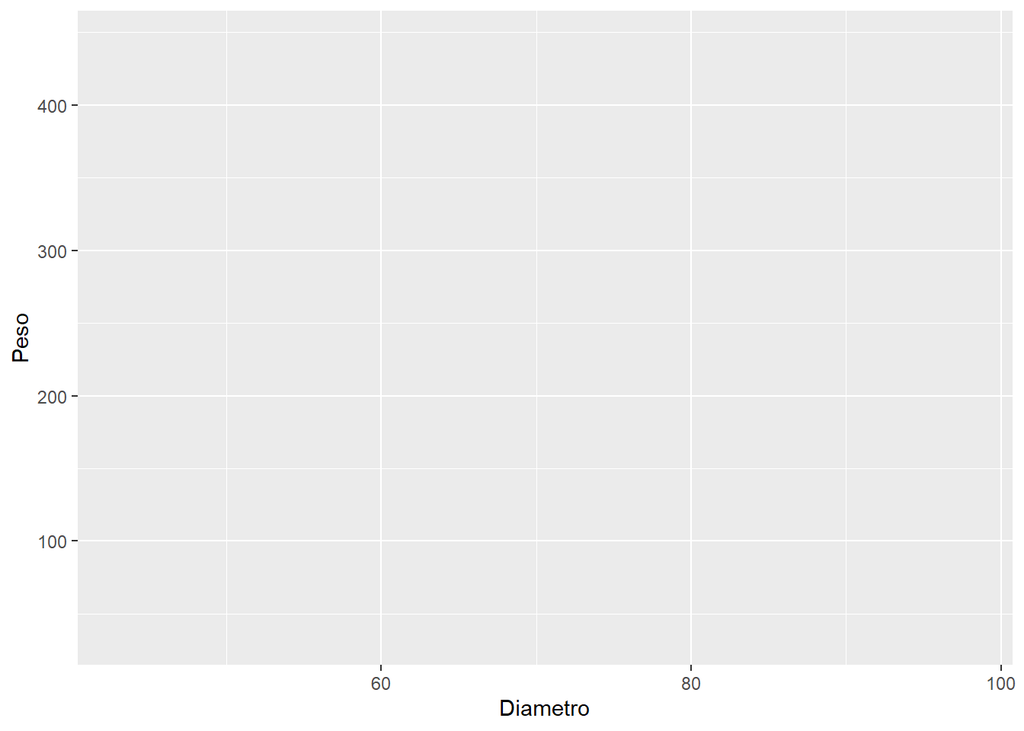

```r
graf1 <- ggplot(pesodiamtod, aes(x=Diametro, y=Peso))
graf1
```

## geom_point()

**Código**

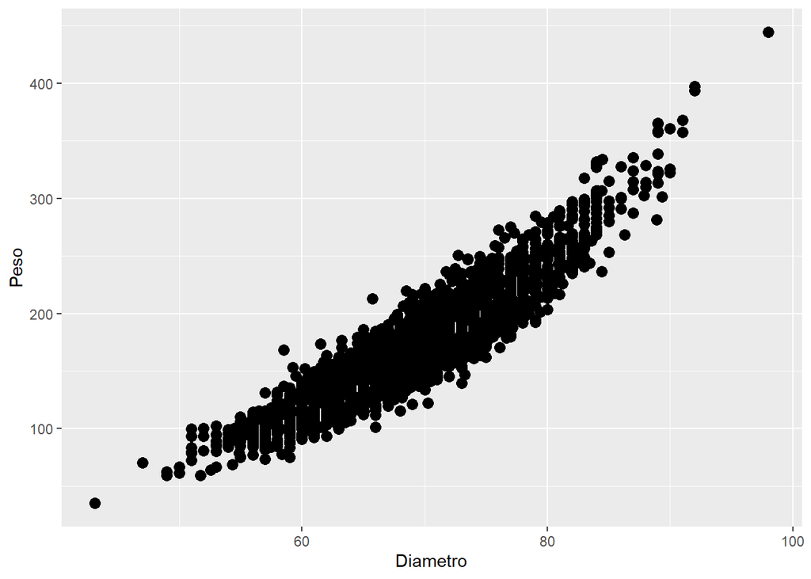

```r
graf1 + geom_point(size=3 )
```

## Densidad de datos

**Código**

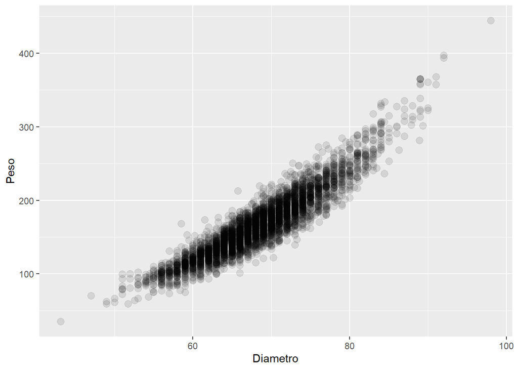

```r
graf1 + geom_point(size=3, alpha = 0.1)
```

## Grafica por especie

Utilizando atributos de los *Glyphs* para diferenciar cultivares.

**Código**

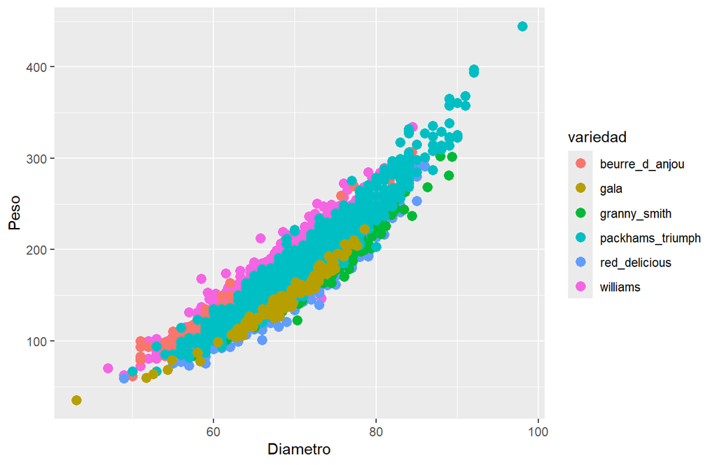

```r
graf1 + geom_point(aes(colour=variedad),size=3)
```

## Utilizando otros glyph

**Código**

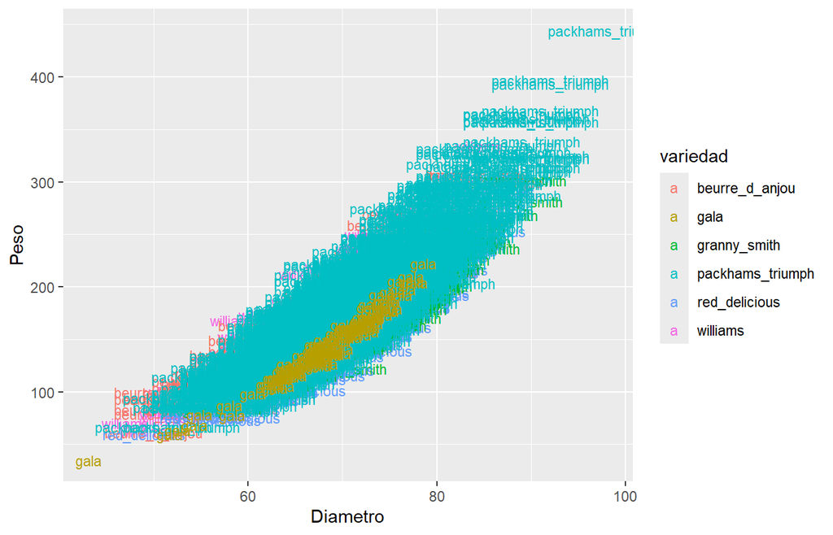

```r
graf1 + geom_text(aes(label = variedad, colour=variedad),size=3)
```

## Escalas

**Código**

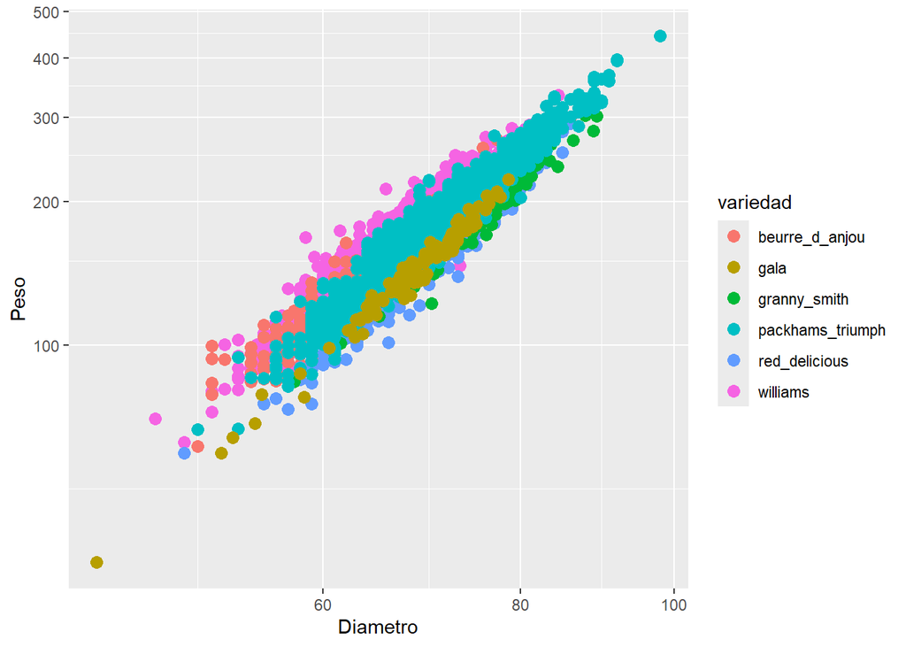

```r
graf1 + geom_point(aes(colour=variedad),size=3) +
  coord_trans(x = "log", y = "log")
```

## Escalas en diferente sistema

**Código**

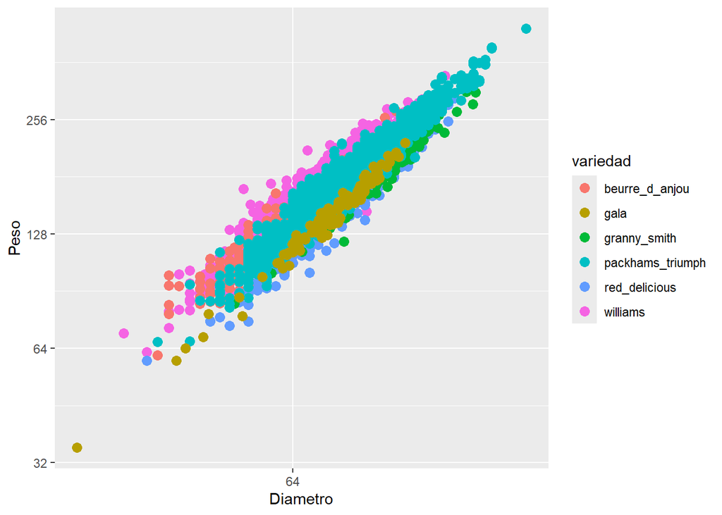

```r
graf1 + geom_point(aes(colour=variedad),size=3) +
  scale_x_continuous(trans='log2') +  scale_y_continuous(trans='log2')
```

## Agregar ticks en X

**Código**

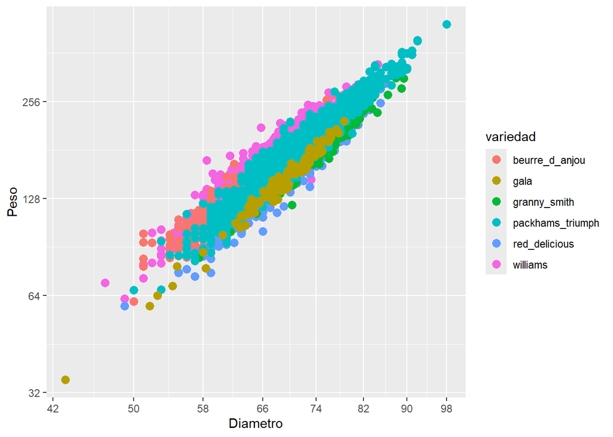

```r
graf1 + geom_point(aes(colour=variedad),size=3) +
  scale_x_continuous(breaks = seq(42, 98, by = 8), trans='log2') + scale_y_continuous(trans='log2')
```

## Identificar entre especies

La función ifelse es un condicional vectorizado.

**Código**

```r
pesodiamtod$Especie <- ifelse(pesodiamtod$variedad %in% c("williams", "beurre_d_anjou", "packhams_triumph"),"Peras", "Manzanas")
head(pesodiamtod,4)
```

```
  Variedad  Peso Diametro id_variedad variedad Especie
1        1 135.7    63.50           1 williams   Peras
2        1 176.5    67.75           1 williams   Peras
3        1 210.6    72.75           1 williams   Peras
4        1 161.0    66.00           1 williams   Peras
```

## Facetas

- Son múltiples paneles dispuestos uno al lado de otro.
- Se utiliza cuando el gráfico se torna difícil de leer.
- Hay una nueva variable clasificatoria y no existen mas glyphs.

## Actualizar objeto guardado

**Código**

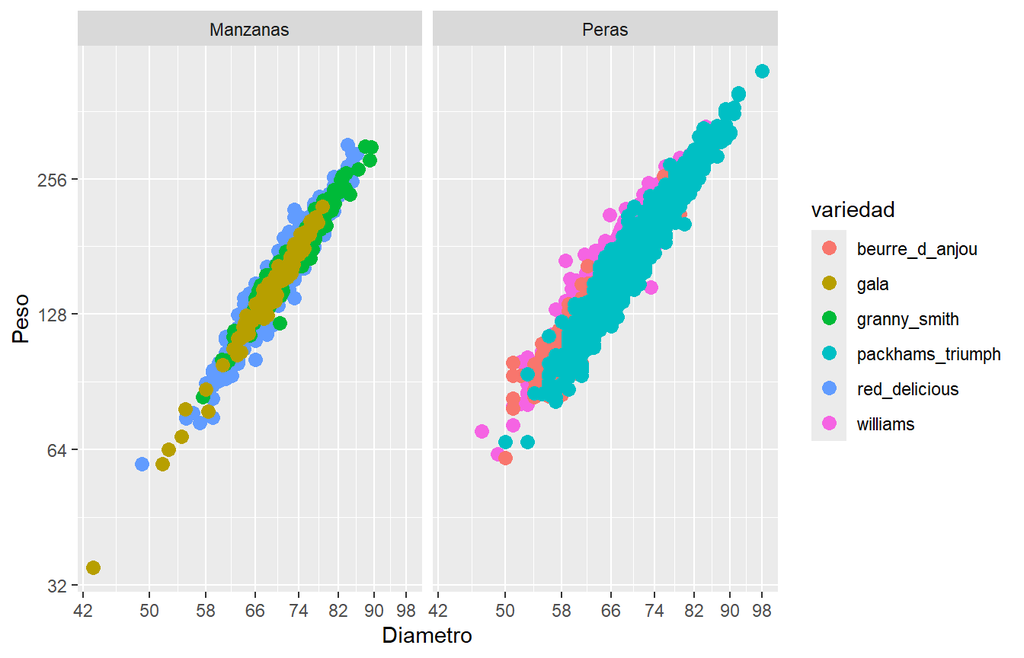

```r
graf2  <- ggplot(pesodiamtod, aes(x=Diametro, y=Peso))
graf2 + geom_point(aes(colour=variedad),size=3) +
  scale_x_continuous(breaks = seq(42, 98, by = 8),trans='log2') +  scale_y_continuous(trans='log2')+facet_wrap(~Especie)
```

## Gráfica por especie y variedad

**Código**

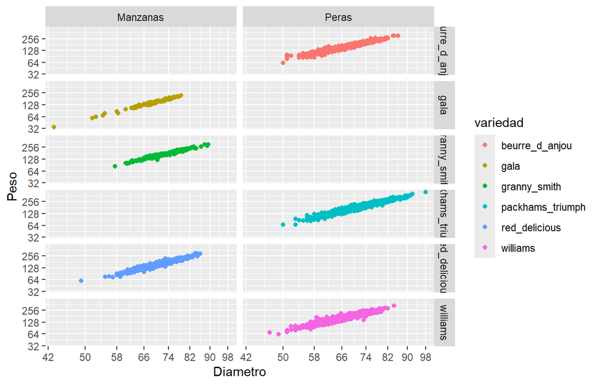

```r
ggplot(pesodiamtod, aes(x=Diametro, y=Peso, colour = variedad)) + geom_point()+
   scale_x_continuous(breaks = seq(42, 98, by = 8),trans='log2') +
  scale_y_continuous(trans='log2')+facet_grid(variedad~Especie)
```

## Gráfica por especie y variedad

**Código**

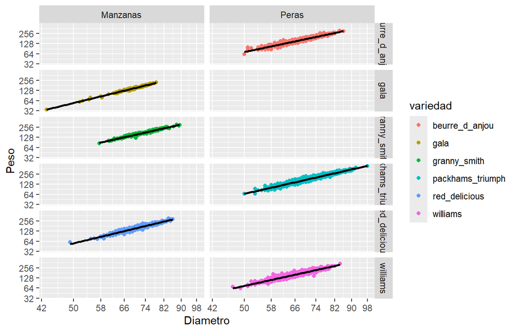

```r
ggplot(pesodiamtod, aes(x=Diametro, y=Peso, colour = variedad)) + geom_point()+
   scale_x_continuous(breaks = seq(42, 98, by = 8),trans='log2') +
  scale_y_continuous(trans='log2') + facet_grid(variedad~Especie)+ geom_smooth(method = lm, se=F, colour="black")
```

## themes

> Son una forma de personalizar los componentes que no son datos de sus gráficos: títulos, etiquetas, fuentes, fondo, líneas de cuadrícula y leyendas.

Hay temas completos disponibles como  
* theme_bw() * theme_minimal() * theme_gray() y más.

## themes preconfigurados 1

**Código**

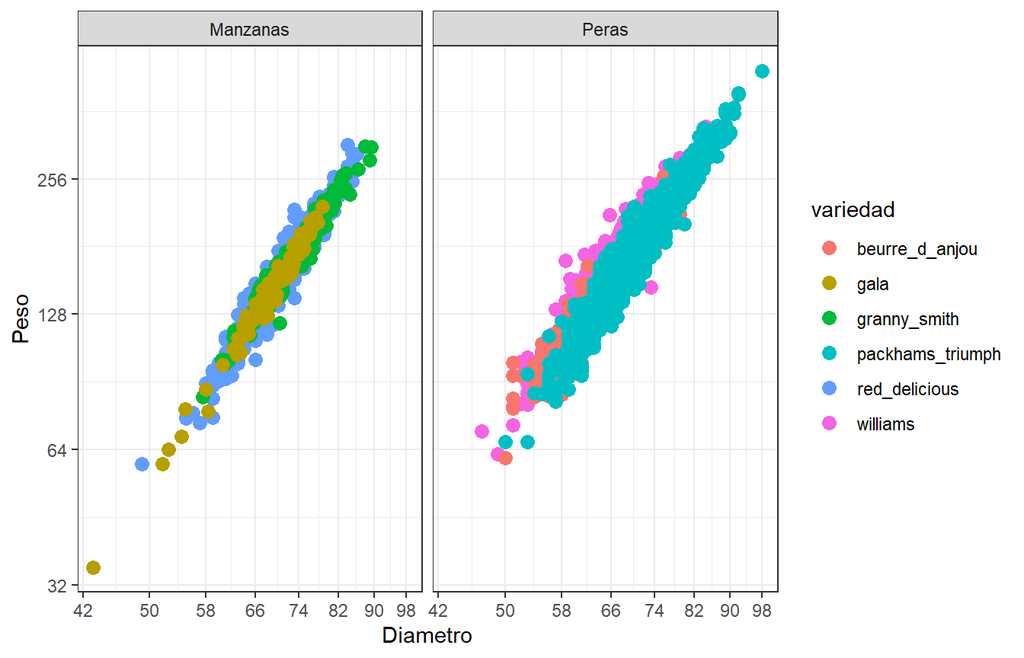

```r
graf2  <- ggplot(pesodiamtod, aes(x=Diametro, y=Peso))
graf2 + geom_point(aes(colour=variedad),size=3) +
  scale_x_continuous(breaks = seq(42, 98, by = 8),trans='log2') +  scale_y_continuous(trans='log2')+facet_wrap(~Especie) + theme_bw()
```